# Ford GoBike Usage Habits By Gender and Age

## Investigation Overview

For this investigation, I examined Ford GoBike data to see how members of different genders and age groups are represented and how they use the service. This exploration covered number of rides per age and gender, age makeup by gender, ride times, distance, and ride duration.

## Dataset Overview

The dataset contained information pertaining to around 1,750,000 rides during 2018. The information covered areas including rider gender, age, time of ride, ride duration, starting and ending location, and other details including bike id, type of user, station name, and more. 111,594 results were removed due to missiong or presumably inaccurate information.

```python
HTML('''<script>
code_show=true;
function code_toggle() {
 if (code_show){
 $('div.input').hide();
 } else {
 $('div.input').show();
 }
 code_show = !code_show
}
$( document ).ready(code_toggle);
</script>
The code for this project has been hidden for easier viewing.
To re-enable it, please click <a href="javascript:code_toggle()">here</a>. Code source: http://blog.nextgenetics.net/?e=102''')
```

The code for this project has been hidden for easier viewing. To re-enable it, please click here. Code source: http://blog.nextgenetics.net/?e=102

## Distribution by Gender

The gender breakdown of rides by gender leans heavily towards males with over 1.2 million rides. Rides by females account for around 400,000 rides while those identifying as *other* number around 27,000.

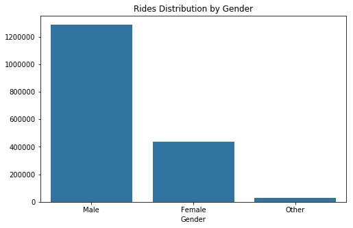

```python
base_color = sb.color_palette()[0]
plt.figure(figsize=[8, 5])
sb.countplot(data=ride_df, x='member_gender', color=base_color, order=['Male', 'Female', 'Other'])
plt.xlabel('Gender')
plt.title('Rides Distribution by Gender')
plt.ylabel('');
```

## Distribution by Birth Year

Ages in the GoBike data begin steadly rising for birth years from around 1960 to 1980 where we see a steep increase peaking around the year 1989. These numbers begin to trail off for birth years in the 90's until it stops at what is presumably the latest year, the year 2000, a user is allowed to signup due to age restrictions. The data takes on a unimodal shape.

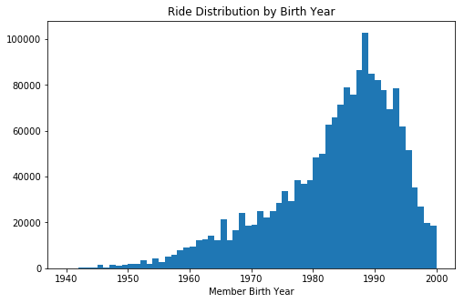

```python
# Binsize of 1 for every year
binsize = 1
bins = np.arange(1940, ride_df['member_birth_year'].max()+binsize, binsize)
plt.figure(figsize=[8, 5])
plt.hist(data = ride_df, x = 'member_birth_year', bins=bins)
plt.xlabel('Member Birth Year')
plt.title('Ride Distribution by Birth Year')
plt.show()
```

## Birth Year Distriubtion by Gender

Birth year distribution by gender shows that the age distribution among these groups is relatively similar with the highest concentration taking place in the 80's. Females tend to have slightly younger riders than the other two groups (mostly between 1980 and 1991). Males have the largest interquartile range which extending from the late 70's to the early 90's. The other group ages appear to fit somewhere the concentrations of male and female ages.

[figure not shown]

```python
plt.figure(figsize=[8, 5])
sb.boxplot(data=ride_df, x='member_gender', y='member_birth_year')
plt.xlabel('Gender')
plt.ylabel('Birth Year')
plt.title('Birth Year Distribution by Gender');
```

## Average Ride Time by Gender

Plotting the average duration of ride times by gender reveals that females a likely to have longer rides than males or members within the other group. While males make up and overwhelming number of rides that take place in the GoBike service, their average ride duration (around 733 seconds) is considerably less that of females (roughly 901 seconds). As with the age distribution, users within the other category fit in-between these groups with an average ride time of around 867 seconds.

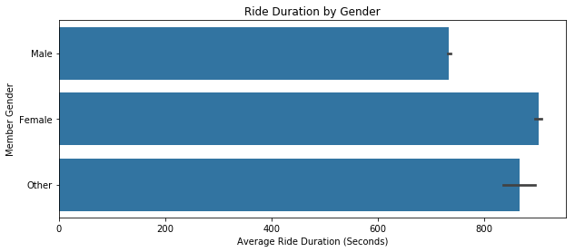

```python
# Calculate average ride times by age and gender
# Source: https://seaborn.pydata.org/generated/seaborn.barplot.html
make_means = ride_df.groupby('member_gender').mean()
comb_order = make_means.sort_values('duration_sec', ascending = False).index

base_color = sb.color_palette()[0]
plt.figure(figsize=[10, 4])
sb.barplot(data = ride_df, x = 'duration_sec', y = 'member_gender', color = base_color)
plt.xlabel('Average Ride Duration (Seconds)')
plt.title('Ride Duration by Gender')
plt.ylabel('Member Gender');
```

## Ride Volume Per Day for Each Gender

By observing the ride volume per day across all genders, we can infer that Monday - Friday is the most popular time for making use of the GoBike service. These figures reach their highest points towards the middle of the week and drop shaprly during the weekend. This may be due to the GoBike service being used during work commutes, but there is not enough information in the data fully support this claim.

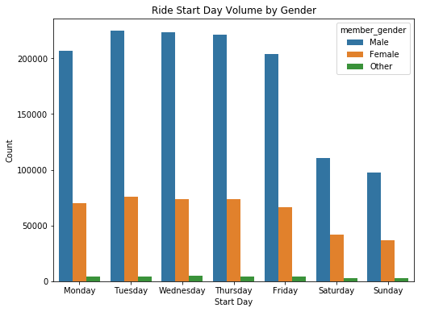

```python
plt.figure(figsize=[8, 6])
day_chart = sb.countplot(x="start_day", hue="member_gender", data=ride_df, \
             order=['Monday', 'Tuesday', 'Wednesday', 'Thursday', 'Friday', 'Saturday', 'Sunday'])
day_chart.set_xlabel('Start Day')
day_chart.set_ylabel('Count')
day_chart.set_title('Ride Start Day Volume by Gender');
```

## Ride Distance Between Start an End Stations By Gender and Age

[figure not shown]

```python
# Source: https://seaborn.pydata.org/tutorial/axis_grids.html
bins_x = np.arange(1920, 2000 + 1, 5)
bins_y = np.arange(0, 13, 1)

def heatgrid(x, y, **kwargs):
    plt.hist2d(x, y, cmap='viridis_r', bins=[bins_x, bins_y], cmin=0.5)

with sb.axes_style("white"):
    g = sb.FacetGrid(ride_df, hue="member_gender", col="member_gender", size=4, col_wrap=2)
g.map(heatgrid, "member_birth_year", "distance_between_stations")

# Source: https://stackoverflow.com/questions/29813694/how-to-add-a-title-to-seaborn-facet-plot
plt.subplots_adjust(top=0.9)
g.fig.suptitle('Ride Distance (Miles) Between Start and End Stations by Gender and Age')
plt.ylim(0,14);
```